# IODS course project

Pentti Henttonen

# Introduction to Open Data Science - Course Project

*About the project*

#I am feeling rather bad at the moment, due to having flu. Hard to work with code when bright lights hurt your eyes. Otherwise I am fine. I heard from this course from the big man Kimmo himself. As stated in the introductions, I have some experience with SPSS and Matlab. I started using R 2-3 years ago and have had good experience with it. But, if I have had to do something statistical fast I have always turned to SPSS. Also, if I have had to do some operating with data I have used Matlab since I am familiar with the syntax. After this course I hope to have internalized R to the point that I can stop going back to those “legacy modes”. Mastering version control is a big part of this process and likely needed in my future projects.

#Went through the exercises#1 and the book. Most of the things were familiar to me, at least somewhat. Having also taught in one course (combined R/SPSS), I think the hard part of teaching R is that there are so many overlapping ways to achieve things, making the creation of sample material hard, especially at the start when student are just copypasting blindly. Then, they encounter another way of doing it, which confuses them. However, the material here and in the book is doing a good job. One can see that a large effort has been made to produce it.

#Cleaned this up a little after comments!!!

# Chapter 2: Regression and modeling

*#Part 1: Read and describe the data*

```r
d0 <-read.csv('data/learning2014.csv')
str(d0)
```

```
## 'data.frame':    166 obs. of  7 variables:
##  $ gender  : chr  "F" "M" "F" "M" ...
##  $ Age     : int  53 55 49 53 49 38 50 37 37 42 ...
##  $ Attitude: num  3.7 3.1 2.5 3.5 3.7 3.8 3.5 2.9 3.8 2.1 ...
##  $ Deep    : num  3.58 2.92 3.5 3.5 3.67 ...
##  $ Stra    : num  3.38 2.75 3.62 3.12 3.62 ...
##  $ Surf    : num  2.58 3.17 2.25 2.25 2.83 ...
##  $ Points  : int  25 12 24 10 22 21 21 31 24 26 ...
```

```r
dim(d0)
```

```
## [1] 166   7
```

```r
head(d0)
```

```
##   gender Age Attitude     Deep  Stra     Surf Points
## 1      F  53      3.7 3.583333 3.375 2.583333     25
## 2      M  55      3.1 2.916667 2.750 3.166667     12
## 3      F  49      2.5 3.500000 3.625 2.250000     24
## 4      M  53      3.5 3.500000 3.125 2.250000     10
## 5      M  49      3.7 3.666667 3.625 2.833333     22
## 6      F  38      3.8 4.750000 3.625 2.416667     21
```

```r
#This data was collected 2014-2015. It includes 166 observations from 183 original participants who had nonzero total exam points (Points). Variables consist of the exam points (Points), two demographical variables, age and gender, along with four scaled sum scores denoting Attitude towards statistics (Attitude), Deep- (Deep), Strategic- (Strat) and Surface (Surf) approaches to #learning
```

*Part 2: Graphical overview and summaries*

```r
#Add required libraries
library(psych)
library(corrplot)
#Overall descriptives and frequencies for gender using psych::describe library
describe(d0)
```

```
##          vars   n  mean   sd median trimmed  mad   min   max range  skew
## gender*     1 166  1.34 0.47   1.00    1.30 0.00  1.00  2.00  1.00  0.68
## Age         2 166 25.51 7.77  22.00   23.99 2.97 17.00 55.00 38.00  1.89
## Attitude    3 166  3.14 0.73   3.20    3.15 0.74  1.40  5.00  3.60 -0.08
## Deep        4 166  3.68 0.55   3.67    3.70 0.62  1.58  4.92  3.33 -0.50
## Stra        5 166  3.12 0.77   3.19    3.14 0.83  1.25  5.00  3.75 -0.11
## Surf        6 166  2.79 0.53   2.83    2.78 0.62  1.58  4.33  2.75  0.14
## Points      7 166 22.72 5.89  23.00   23.08 5.93  7.00 33.00 26.00 -0.40
##          kurtosis   se
## gender*     -1.54 0.04
## Age          3.24 0.60
## Attitude    -0.48 0.06
## Deep         0.66 0.04
## Stra        -0.45 0.06
## Surf        -0.27 0.04
## Points      -0.26 0.46
```

```r
table(d0$gender)
```

```
##
##   F   M
## 110  56
```

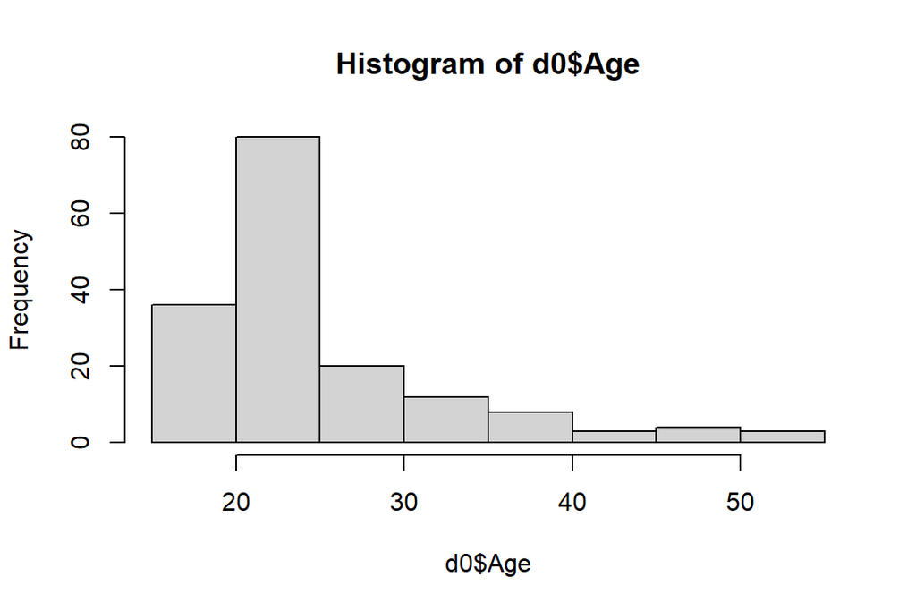

```r
#Histograms
hist(d0$Age)
```

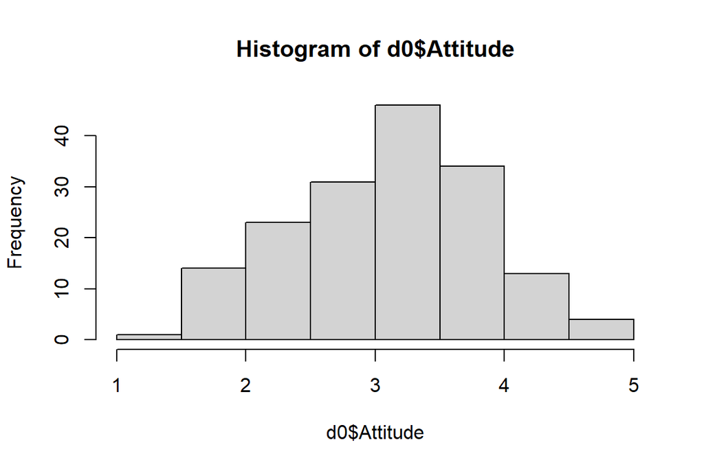

```r
hist(d0$Attitude)
```

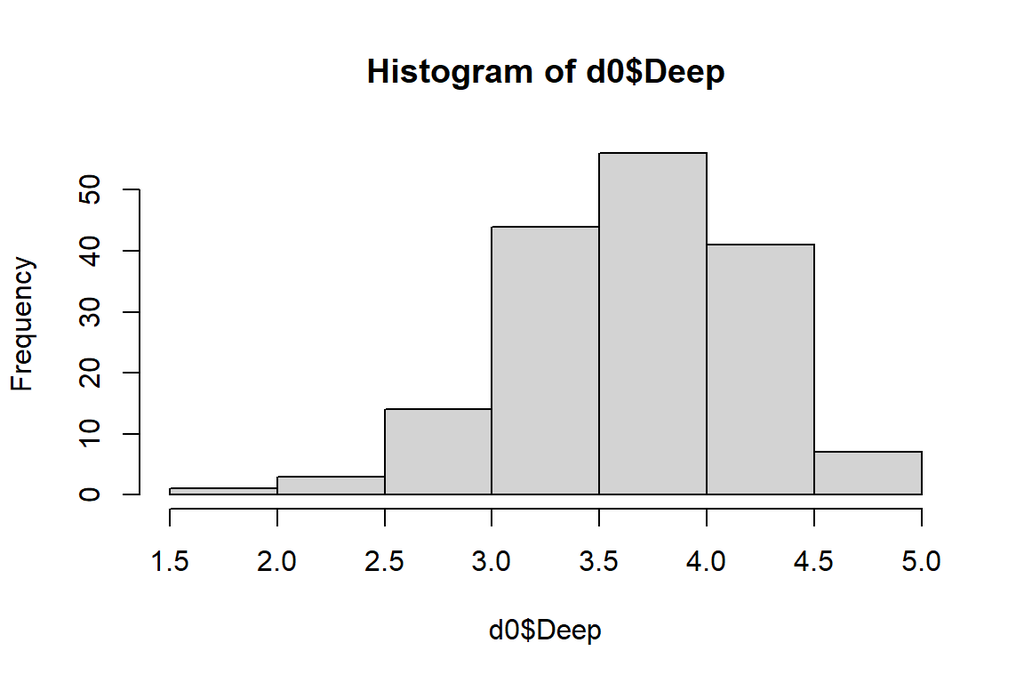

```r
hist(d0$Deep)
```

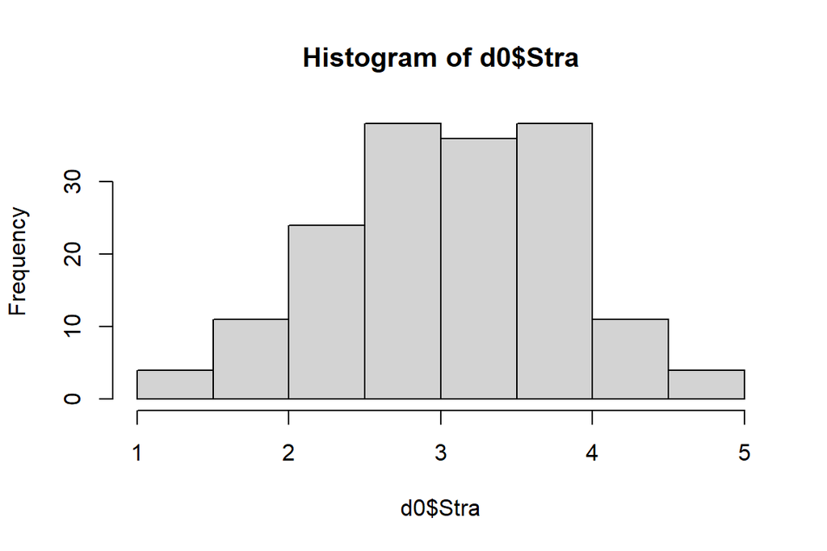

```r
hist(d0$Stra)
```

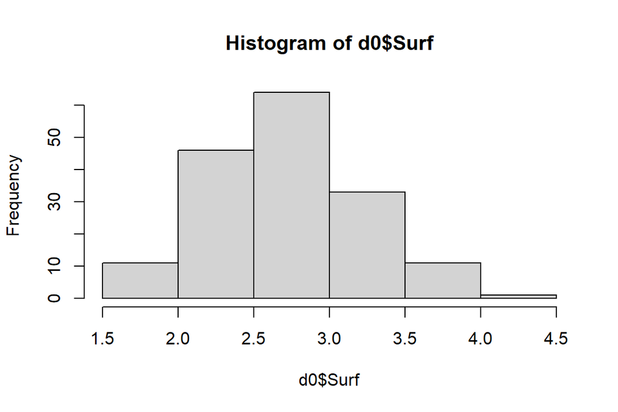

```r
hist(d0$Surf)
```

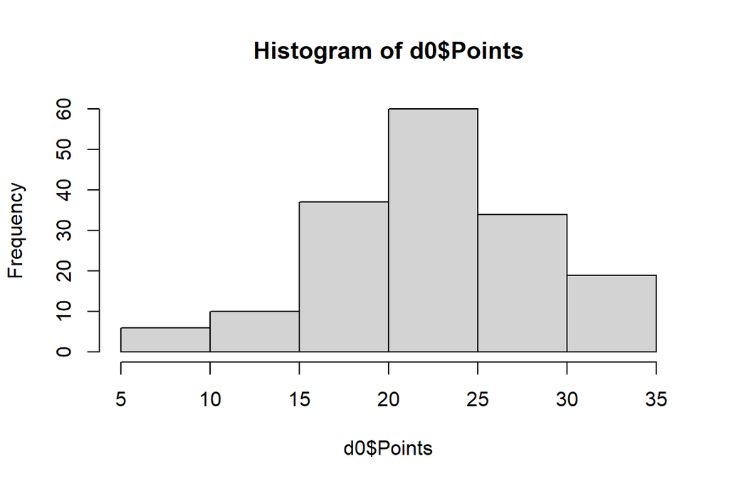

```r
hist(d0$Points)
```

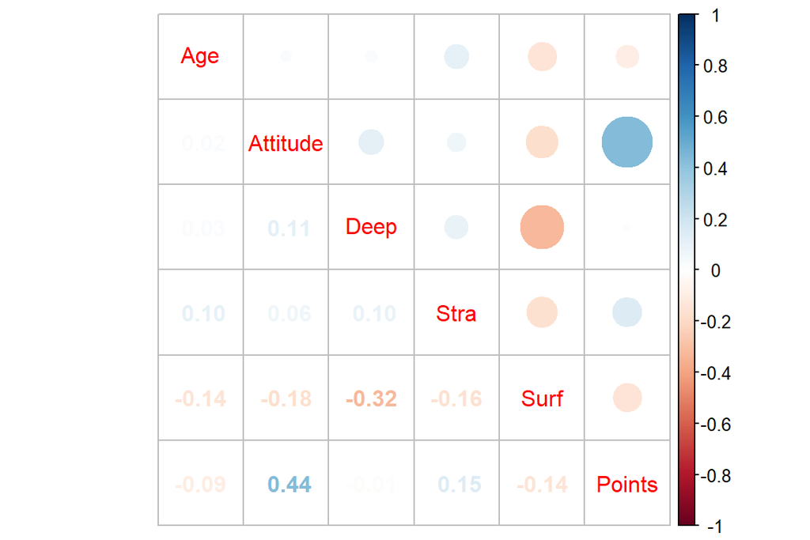

```r
#Variables look relatively normal, there are no skewness or kurtosis values above 1, Except for Age, which is understandable. As usual, there are more female participants.

#Correlation plot between continuous variables using corrplot library
corrplot.mixed(cor(d0[,2:7], use = "pairwise"))
```

```r
#There is a substantial positive correlation between Attitude towards statistics and Exam points (r=0.44). Also, Surface approach to learning has negative correlation profile (r=-0.14--0.32) with all other variables, including age. Largest negative association (r=-0.32) is between Surface and Deep learning strategies.
```

*Part 3: Regression model predicting Exam points*

```r
#Specify the regression model. After exploratory iterations, these are the three predictors which have p<0.10 significance levels (Age,Attitude and Strategic learning)
lm.1 = lm(Points~Age+Attitude+Stra, data = d0)
summary(lm.1)
```

```
##
## Call:
## lm(formula = Points ~ Age + Attitude + Stra, data = d0)
##
## Residuals:
##      Min       1Q   Median       3Q      Max
## -18.1149  -3.2003   0.3303   3.4129  10.7599
##
## Coefficients:
##             Estimate Std. Error t value Pr(>|t|)
## (Intercept) 10.89543    2.64834   4.114 6.17e-05 ***
## Age         -0.08822    0.05302  -1.664   0.0981 .
## Attitude     3.48077    0.56220   6.191 4.72e-09 ***
## Stra         1.00371    0.53434   1.878   0.0621 .
## ---
## Signif. codes:  0 '***' 0.001 '**' 0.01 '*' 0.05 '.' 0.1 ' ' 1
##
## Residual standard error: 5.26 on 162 degrees of freedom
## Multiple R-squared:  0.2182, Adjusted R-squared:  0.2037
## F-statistic: 15.07 on 3 and 162 DF,  p-value: 1.07e-08
```

```r
#Model has significant predictive power in general [F(3,162)=15.07, p<0.001].
```

*Part 4: Model parameters*

```r
summary(lm.1)
```

```
##
## Call:
## lm(formula = Points ~ Age + Attitude + Stra, data = d0)
##
## Residuals:
##      Min       1Q   Median       3Q      Max
## -18.1149  -3.2003   0.3303   3.4129  10.7599
##
## Coefficients:
##             Estimate Std. Error t value Pr(>|t|)
## (Intercept) 10.89543    2.64834   4.114 6.17e-05 ***
## Age         -0.08822    0.05302  -1.664   0.0981 .
## Attitude     3.48077    0.56220   6.191 4.72e-09 ***
## Stra         1.00371    0.53434   1.878   0.0621 .
## ---
## Signif. codes:  0 '***' 0.001 '**' 0.01 '*' 0.05 '.' 0.1 ' ' 1
##
## Residual standard error: 5.26 on 162 degrees of freedom
## Multiple R-squared:  0.2182, Adjusted R-squared:  0.2037
## F-statistic: 15.07 on 3 and 162 DF,  p-value: 1.07e-08
```

```r
#The best and only significant positive predictor of Exam points in the model is Attitude towards statistics (p<0.001). Strategic thinking has a trending positive effect (p=0.06), while Age has a trending negative effect (p=0.10). This three predictor model explains one fifth of the variance in Exam points (adj. R2=0.20). This is a only a moderate amount, as 4/5 of the variance remains unexplained.
```

*Part 5: Model diagnostics*

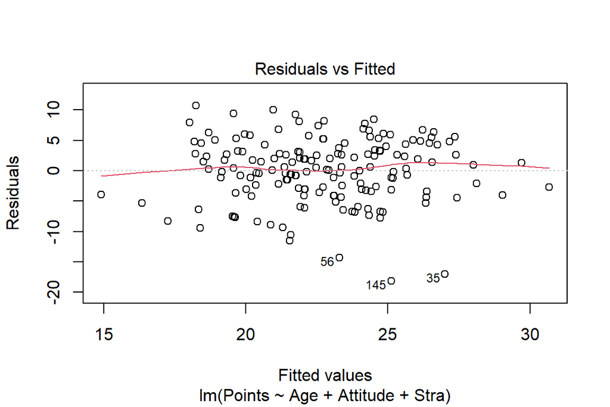

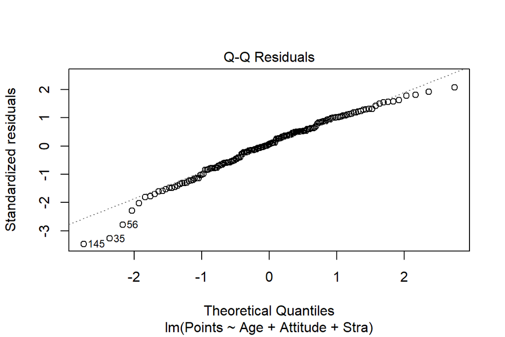

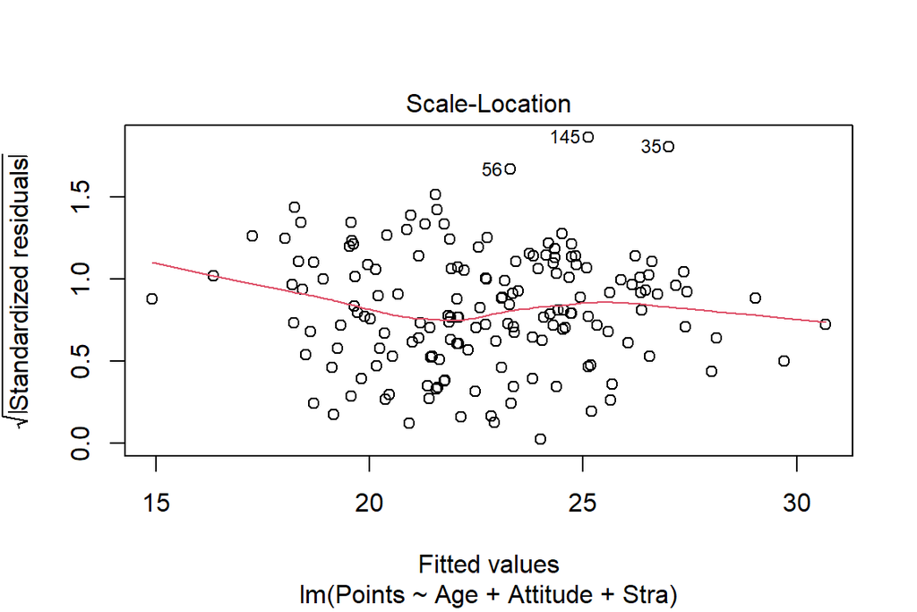

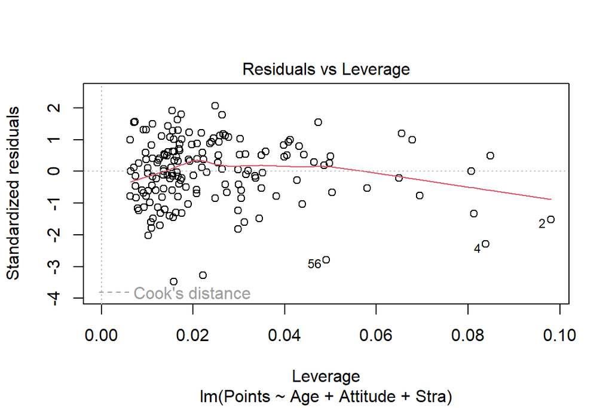

```r
#Producing plot with the simple plot command on model. This produces four plots, of which the third (Scale-Location) was not requested in the task description but here it is anyway.
plot(lm.1)
```

```r
#Looking at the three requested plots:

#Residuals vs Fitted: Assumption is that distribution of residuals does not vary depending on the fitted values. In plot, the red line should be horizontal:  it is.

#QQ residuals: Assumption is that the residuals are normally distributed. In plot, the residuals should follow diagonal: they do, with some deviations at the extreme ends.

#Residuals vs Leverage: Standardized residuals vs. leverage should not show points that reach outside the curved areas of Cook’s distance of 1, which would indicate highly influential outliers. In plot, we do not see the Cook's distance lines so there are no excessively problematic outliers.
```

# Chapter 3: Logistic regression

load required libraries

```r
library(tidyverse)
```

```
## ✖ ggplot2::%+%()   masks psych::%+%()
```

```r
library(psych)
```

### Part 2: Read and describe the data

```r
d0 <-read.csv('data/alcohol.csv')
ls(d0)
```

```
##  [1] "absences"   "activities" "address"    "age"        "alc_use"
##  [6] "Dalc"       "failures"   "famrel"     "famsize"    "famsup"
## [11] "Fedu"       "Fjob"       "freetime"   "G1"         "G2"
## [16] "G3"         "goout"      "guardian"   "health"     "high_use"
## [21] "higher"     "internet"   "Medu"       "Mjob"       "nursery"
## [26] "paid"       "Pstatus"    "reason"     "romantic"   "school"
## [31] "schoolsup"  "sex"        "studytime"  "traveltime" "Walc"
```

Data consists of observations from participants in secondary education of two Portuguese schools. The data attributes include student grades, demographic, social and school related features, and it was collected by using school reports and questionnaires. More info at:https://www.archive.ics.uci.edu/dataset/320/student+performance

### Part 3: Choosing variables related to high/low alcohol consumption

I am choosing the following 4 variables, in order to test historian Teemu Keskisarja’s recent claim that students nowadays don’t drink alcohol, instead spending their time getting depressed online. Would prefer Finnish data, but Portuguese will have to do.

1. internet - Internet access at home
- binary: yes or no
- I predict strong negative effect for having internet. This is the main hypothesis.
2. Medu - mother’s education
- numeric: 0 - none, 1 - primary education (4th grade), 2 – 5th to 9th grade, 3 – secondary education or 4 – higher education
- Always good to include mother’s education. I predict a negative effect.
3. activities - extra-curricular activities
- binary: yes or no
- This is more exploratory. Expect a small negative effect. Nerds drink less.
4. romantic - with a romantic relationship
- binary: yes or no
- Alcohol is a strong predictor or initiation of romantic relationships. Vast evidence exist.

Let’s plot the variables. Also, let’s make the mothers education variable binary (yes/no secoondary education).

### Part 4: Exploring the variables.

*Individual distibutions look relatively ok, internet use is fairly prevalent. Let’s have a look at crosstabs and do some chi square tests to see relationships of predictors to dependent variable*

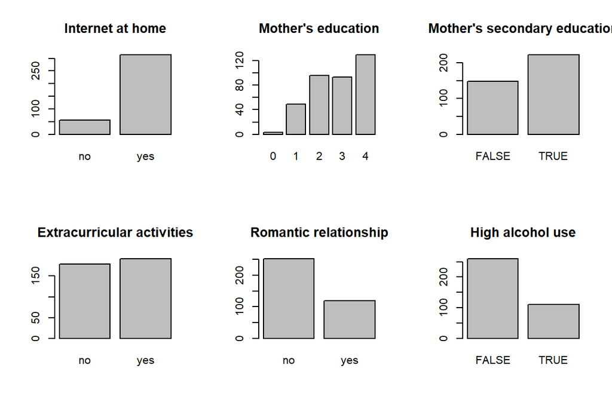

```r
par(mfrow = c(2,3))
barplot(table(d0$internet), main="Internet at home")
barplot(table(d0$Medu),main="Mother's education")
d0 <- mutate(d0, moth_high = Medu> 2)
barplot(table(d0$moth_high),main="Mother's secondary education")
barplot(table(d0$activities),main="Extracurricular activities")
barplot(table(d0$romantic),main="Romantic relationship")
barplot(table(d0$high_use),main="High alcohol use")
```

#### Internet use: no effect

```r
table(d0$internet, d0$high_use)
```

```
##
##       FALSE TRUE
##   no     42   15
##   yes   217   96
```

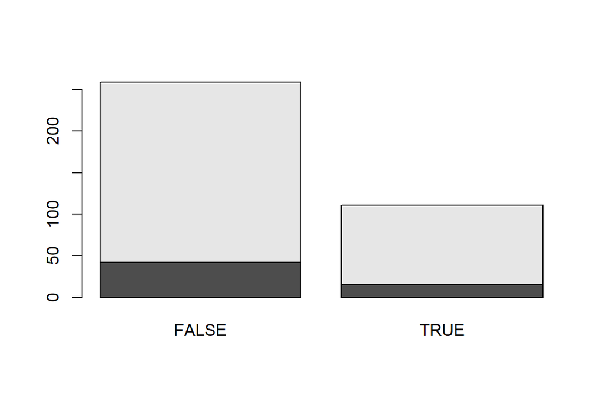

```r
barplot(table(d0$internet, d0$high_use))
```

```r
chisq.test(d0$internet,d0$high_use)
```

```
##
##  Pearson's Chi-squared test with Yates' continuity correction
##
## data:  d0$internet and d0$high_use
## X-squared = 0.25282, df = 1, p-value = 0.6151
```

#### Mother’s secondary education: no effect

```r
table(d0$moth_high, d0$high_use)
```

```
##
##         FALSE TRUE
##   FALSE   110   38
##   TRUE    149   73
```

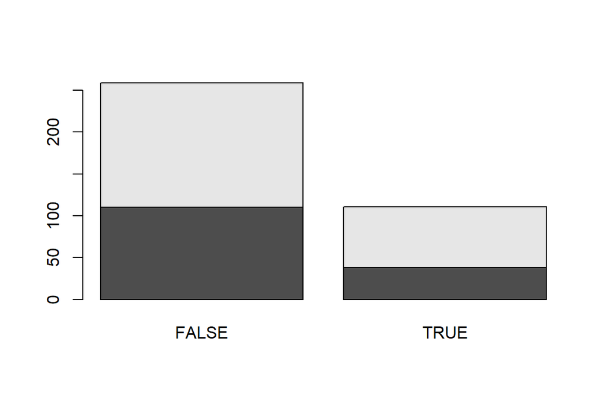

```r
barplot(table(d0$moth_high, d0$high_use))
```

```r
chisq.test(d0$moth_high,d0$high_use)
```

```
##
##  Pearson's Chi-squared test with Yates' continuity correction
##
## data:  d0$moth_high and d0$high_use
## X-squared = 1.8667, df = 1, p-value = 0.1719
```

#### Extracurricular activities: no effect

```r
table(d0$activities, d0$high_use)
```

```
##
##       FALSE TRUE
##   no    120   59
##   yes   139   52
```

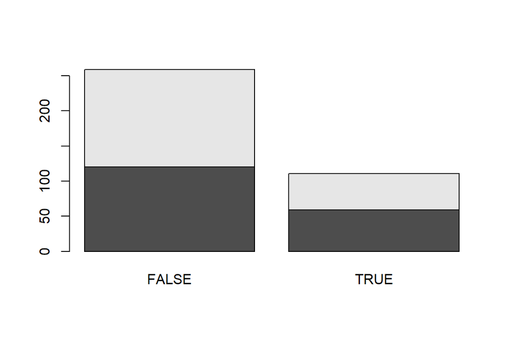

```r
barplot(table(d0$activities, d0$high_use))
```

```r
chisq.test(d0$activities,d0$high_use)
```

```
##
##  Pearson's Chi-squared test with Yates' continuity correction
##
## data:  d0$activities and d0$high_use
## X-squared = 1.1873, df = 1, p-value = 0.2759
```

#### Romantic relationship: no effect

```r
table(d0$romantic, d0$high_use)
```

```
##
##       FALSE TRUE
##   no    173   78
##   yes    86   33
```

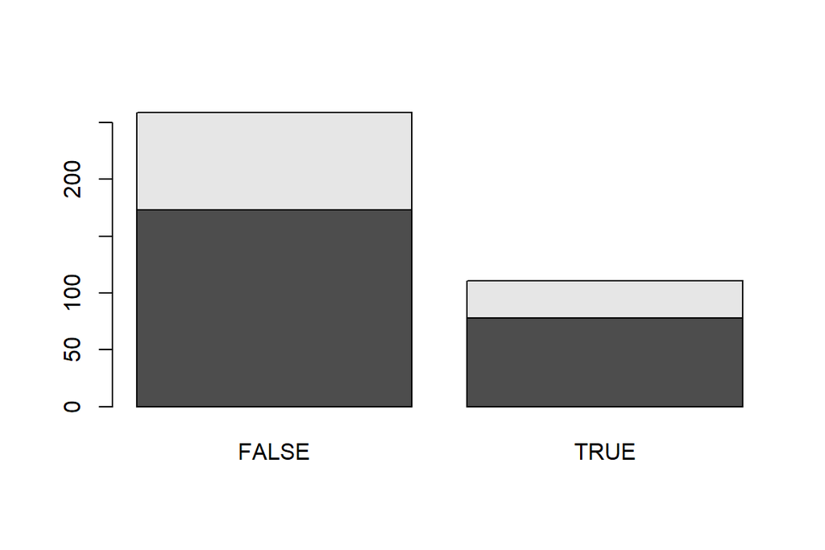

```r
barplot(table(d0$romantic, d0$high_use))
```

```r
chisq.test(d0$romantic,d0$high_use)
```

```
##
##  Pearson's Chi-squared test with Yates' continuity correction
##
## data:  d0$romantic and d0$high_use
## X-squared = 0.2855, df = 1, p-value = 0.5931
```

#### Seems that none of my variables individually predict high alcohol use, but maybe there’s something when they get controlled by the others. Let’s run the model.

### 5. Logistic regression model

```r
or.model = glm(high_use ~ internet+moth_high+activities+romantic, data = d0, family = "binomial")
summary(or.model)
```

```
##
## Call:
## glm(formula = high_use ~ internet + moth_high + activities +
##     romantic, family = "binomial", data = d0)
##
## Coefficients:
##               Estimate Std. Error z value Pr(>|z|)
## (Intercept)    -1.0301     0.3387  -3.041  0.00235 **
## internetyes     0.1982     0.3313   0.598  0.54965
## moth_highTRUE   0.3488     0.2393   1.458  0.14498
## activitiesyes  -0.2962     0.2294  -1.291  0.19655
## romanticyes    -0.1667     0.2484  -0.671  0.50209
## ---
## Signif. codes:  0 '***' 0.001 '**' 0.01 '*' 0.05 '.' 0.1 ' ' 1
##
## (Dispersion parameter for binomial family taken to be 1)
##
##     Null deviance: 452.04  on 369  degrees of freedom
## Residual deviance: 447.42  on 365  degrees of freedom
## AIC: 457.42
##
## Number of Fisher Scoring iterations: 4
```

```r
confint(or.model)
```

```
##                    2.5 %     97.5 %
## (Intercept)   -1.7222945 -0.3868445
## internetyes   -0.4330116  0.8737188
## moth_highTRUE -0.1157981  0.8241803
## activitiesyes -0.7480795  0.1525509
## romanticyes   -0.6616262  0.3144231
```

The model nor its individual predictors do not do a great job in predicting high alcohol use among students.

### 6. Predictive capacities

*Tried to classify with the above model, could not get it to predict high alcohol use at all. Resorted to using the best predictor, mother’s secondary education, combined with a new variable, going out with friends, to be able to complete the assignment*

Fit the new model

```r
or2.model = glm(high_use ~   moth_high+goout, data = d0, family = "binomial")
summary(or2.model)
```

```
##
## Call:
## glm(formula = high_use ~ moth_high + goout, family = "binomial",
##     data = d0)
##
## Coefficients:
##               Estimate Std. Error z value Pr(>|z|)
## (Intercept)    -3.5013     0.4488  -7.802 6.09e-15 ***
## moth_highTRUE   0.2857     0.2530   1.129    0.259
## goout           0.7525     0.1169   6.440 1.20e-10 ***
## ---
## Signif. codes:  0 '***' 0.001 '**' 0.01 '*' 0.05 '.' 0.1 ' ' 1
##
## (Dispersion parameter for binomial family taken to be 1)
##
##     Null deviance: 452.04  on 369  degrees of freedom
## Residual deviance: 401.76  on 367  degrees of freedom
## AIC: 407.76
##
## Number of Fisher Scoring iterations: 4
```

```r
prob  <- predict(or2.model, type = "response")
d0 <- mutate(d0, probability = prob)
d0 <- mutate(d0, prediction = probability>0.5)
#select(d0, moth_high, activities, high_use, probability, prediction) %>% tail(10)
table(high_use = d0$high_use, prediction = d0$prediction)
```

```
##         prediction
## high_use FALSE TRUE
##    FALSE   238   21
##    TRUE     79   32
```

100/370 (27%) of students were incorrectly classified using the model with the two predictors.

Using the kappa function (from psych library), let’s compare the classification distribution to random guessing.

```r
cohen.kappa(table(high_use = d0$high_use, prediction = d0$prediction),n.obs=370)
```

```
## Call: cohen.kappa1(x = x, w = w, n.obs = n.obs, alpha = alpha, levels = levels)
##
## Cohen Kappa and Weighted Kappa correlation coefficients and confidence boundaries
##                  lower estimate upper
## unweighted kappa  0.14     0.24  0.35
## weighted kappa    0.14     0.24  0.35
##
##  Number of subjects = 370
```

Kappa estimate is 0.24, just above slight agreement. Thus, it can be stated that the prediction performance is above random guessing, but not much. (Landis, JR & Koch, GG (1977). The measurement of observer agreement for categorical data. Biometrics, 33, 159-174))

# Chapter 4: Clustering and classification

load required libraries

```r
library(tidyverse)
library(psych)
library(corrplot)
library(ggplot2)
```

### Part 2: Load and describe the data

```r
# access the MASS package
library(MASS)
# load the data
data("Boston")
#check the data structure and dimensions
str(Boston)
```

```
## 'data.frame':    506 obs. of  14 variables:
##  $ crim   : num  0.00632 0.02731 0.02729 0.03237 0.06905 ...
##  $ zn     : num  18 0 0 0 0 0 12.5 12.5 12.5 12.5 ...
##  $ indus  : num  2.31 7.07 7.07 2.18 2.18 2.18 7.87 7.87 7.87 7.87 ...
##  $ chas   : int  0 0 0 0 0 0 0 0 0 0 ...
##  $ nox    : num  0.538 0.469 0.469 0.458 0.458 0.458 0.524 0.524 0.524 0.524 ...
##  $ rm     : num  6.58 6.42 7.18 7 7.15 ...
##  $ age    : num  65.2 78.9 61.1 45.8 54.2 58.7 66.6 96.1 100 85.9 ...
##  $ dis    : num  4.09 4.97 4.97 6.06 6.06 ...
##  $ rad    : int  1 2 2 3 3 3 5 5 5 5 ...
##  $ tax    : num  296 242 242 222 222 222 311 311 311 311 ...
##  $ ptratio: num  15.3 17.8 17.8 18.7 18.7 18.7 15.2 15.2 15.2 15.2 ...
##  $ black  : num  397 397 393 395 397 ...
##  $ lstat  : num  4.98 9.14 4.03 2.94 5.33 ...
##  $ medv   : num  24 21.6 34.7 33.4 36.2 28.7 22.9 27.1 16.5 18.9 ...
```

```r
summary(Boston)
```

```
##       crim                zn             indus            chas
##  Min.   : 0.00632   Min.   :  0.00   Min.   : 0.46   Min.   :0.00000
##  1st Qu.: 0.08205   1st Qu.:  0.00   1st Qu.: 5.19   1st Qu.:0.00000
##  Median : 0.25651   Median :  0.00   Median : 9.69   Median :0.00000
##  Mean   : 3.61352   Mean   : 11.36   Mean   :11.14   Mean   :0.06917
##  3rd Qu.: 3.67708   3rd Qu.: 12.50   3rd Qu.:18.10   3rd Qu.:0.00000
##  Max.   :88.97620   Max.   :100.00   Max.   :27.74   Max.   :1.00000
##       nox               rm             age              dis
##  Min.   :0.3850   Min.   :3.561   Min.   :  2.90   Min.   : 1.130
##  1st Qu.:0.4490   1st Qu.:5.886   1st Qu.: 45.02   1st Qu.: 2.100
##  Median :0.5380   Median :6.208   Median : 77.50   Median : 3.207
##  Mean   :0.5547   Mean   :6.285   Mean   : 68.57   Mean   : 3.795
##  3rd Qu.:0.6240   3rd Qu.:6.623   3rd Qu.: 94.08   3rd Qu.: 5.188
##  Max.   :0.8710   Max.   :8.780   Max.   :100.00   Max.   :12.127
##       rad              tax           ptratio          black
##  Min.   : 1.000   Min.   :187.0   Min.   :12.60   Min.   :  0.32
##  1st Qu.: 4.000   1st Qu.:279.0   1st Qu.:17.40   1st Qu.:375.38
##  Median : 5.000   Median :330.0   Median :19.05   Median :391.44
##  Mean   : 9.549   Mean   :408.2   Mean   :18.46   Mean   :356.67
##  3rd Qu.:24.000   3rd Qu.:666.0   3rd Qu.:20.20   3rd Qu.:396.23
##  Max.   :24.000   Max.   :711.0   Max.   :22.00   Max.   :396.90
##      lstat            medv
##  Min.   : 1.73   Min.   : 5.00
##  1st Qu.: 6.95   1st Qu.:17.02
##  Median :11.36   Median :21.20
##  Mean   :12.65   Mean   :22.53
##  3rd Qu.:16.95   3rd Qu.:25.00
##  Max.   :37.97   Max.   :50.00
```

The Boston data contains 506 observations (depicting individual towns) of 14 variables describing various information on Housing Values in Suburbs of Boston.

### Part 3: Graphical overview and summaries

```r
#descriptives (psych package)
describe(Boston)
```

```
##         vars   n   mean     sd median trimmed    mad    min    max  range  skew
## crim       1 506   3.61   8.60   0.26    1.68   0.33   0.01  88.98  88.97  5.19
## zn         2 506  11.36  23.32   0.00    5.08   0.00   0.00 100.00 100.00  2.21
## indus      3 506  11.14   6.86   9.69   10.93   9.37   0.46  27.74  27.28  0.29
## chas       4 506   0.07   0.25   0.00    0.00   0.00   0.00   1.00   1.00  3.39
## nox        5 506   0.55   0.12   0.54    0.55   0.13   0.38   0.87   0.49  0.72
## rm         6 506   6.28   0.70   6.21    6.25   0.51   3.56   8.78   5.22  0.40
## age        7 506  68.57  28.15  77.50   71.20  28.98   2.90 100.00  97.10 -0.60
## dis        8 506   3.80   2.11   3.21    3.54   1.91   1.13  12.13  11.00  1.01
## rad        9 506   9.55   8.71   5.00    8.73   2.97   1.00  24.00  23.00  1.00
## tax       10 506 408.24 168.54 330.00  400.04 108.23 187.00 711.00 524.00  0.67
## ptratio   11 506  18.46   2.16  19.05   18.66   1.70  12.60  22.00   9.40 -0.80
## black     12 506 356.67  91.29 391.44  383.17   8.09   0.32 396.90 396.58 -2.87
## lstat     13 506  12.65   7.14  11.36   11.90   7.11   1.73  37.97  36.24  0.90
## medv      14 506  22.53   9.20  21.20   21.56   5.93   5.00  50.00  45.00  1.10
##         kurtosis   se
## crim       36.60 0.38
## zn          3.95 1.04
## indus      -1.24 0.30
## chas        9.48 0.01
## nox        -0.09 0.01
## rm          1.84 0.03
## age        -0.98 1.25
## dis         0.46 0.09
## rad        -0.88 0.39
## tax        -1.15 7.49
## ptratio    -0.30 0.10
## black       7.10 4.06
## lstat       0.46 0.32
## medv        1.45 0.41
```

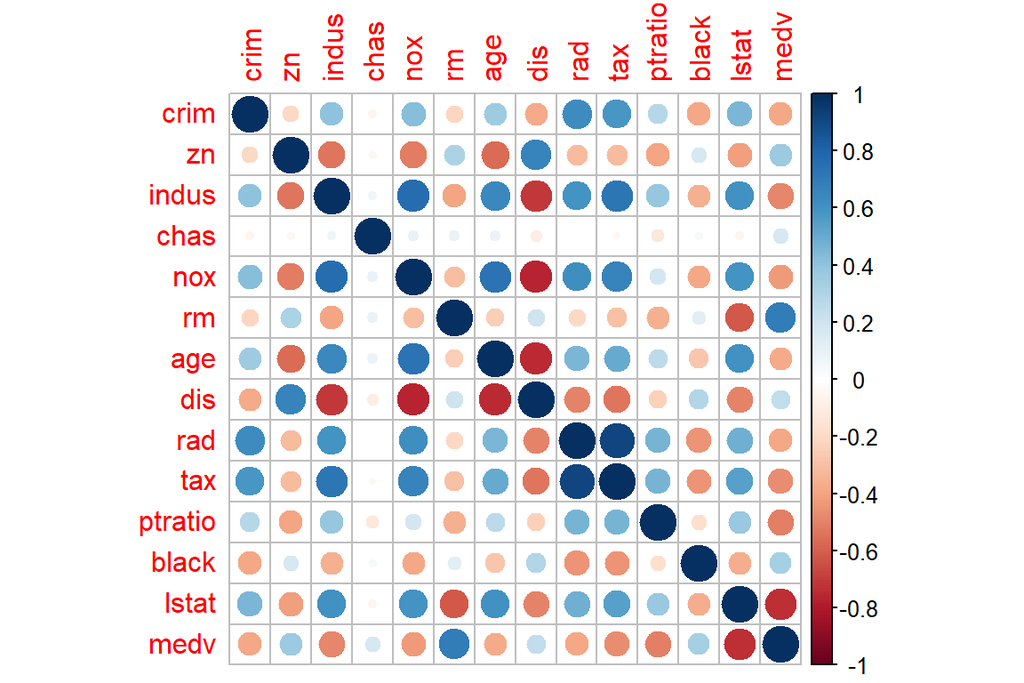

```r
# calculate the correlation matrix
cor_matrix <- cor(Boston)
# visualize the correlation matrix
corrplot(cor_matrix)
```

Three variables exhibit substantial deviations from normality, indicated by large skewness/kurtosis values:

1. crim (per capita crime rate by town)
2. zn (proportion of residential land zoned for lots over 25,000 sq.ft.)
3. black (proportion of blacks by town)

There is also one binary variable:

chas (Charles River dummy variable (= 1 if tract bounds river; 0 otherwise), which does not correlate with any of the other variables

Looking at the correlation matrix, there seems to be one somewhat intercorrelated variable group, containing variables dealing with industrialization:

1. rad (index of accessibility to radial highways)
2. tax (full-value property-tax rate per $10,000)
3. indus (proportion of non-retail business acres per town)
4. nox (nitrogen oxides concentration (parts per 10 million).
5. lstat (lower status of the population (percent).

There are two correlated variable pairs with negative correlations to most other variables:

1. dis (weighted mean of distances to five Boston employment centres)
2. zn (proportion of residential land zoned for lots over 25,000 sq.ft.)

and

1. rm (average number of rooms per dwelling.)
2. medv (median value of owner-occupied homes in $1000s)

### Part 4: Standardization of variables, categorical crime rate and training/test set creation

```r
#scale the data
boston_scaled <- as.data.frame(scale(Boston))
describe(boston_scaled)
```

```
##         vars   n mean sd median trimmed  mad   min  max range  skew kurtosis
## crim       1 506    0  1  -0.39   -0.22 0.04 -0.42 9.92 10.34  5.19    36.60
## zn         2 506    0  1  -0.49   -0.27 0.00 -0.49 3.80  4.29  2.21     3.95
## indus      3 506    0  1  -0.21   -0.03 1.37 -1.56 2.42  3.98  0.29    -1.24
## chas       4 506    0  1  -0.27   -0.27 0.00 -0.27 3.66  3.94  3.39     9.48
## nox        5 506    0  1  -0.14   -0.08 1.12 -1.46 2.73  4.19  0.72    -0.09
## rm         6 506    0  1  -0.11   -0.05 0.73 -3.88 3.55  7.43  0.40     1.84
## age        7 506    0  1   0.32    0.09 1.03 -2.33 1.12  3.45 -0.60    -0.98
## dis        8 506    0  1  -0.28   -0.12 0.91 -1.27 3.96  5.22  1.01     0.46
## rad        9 506    0  1  -0.52   -0.09 0.34 -0.98 1.66  2.64  1.00    -0.88
## tax       10 506    0  1  -0.46   -0.05 0.64 -1.31 1.80  3.11  0.67    -1.15
## ptratio   11 506    0  1   0.27    0.10 0.79 -2.70 1.64  4.34 -0.80    -0.30
## black     12 506    0  1   0.38    0.29 0.09 -3.90 0.44  4.34 -2.87     7.10
## lstat     13 506    0  1  -0.18   -0.11 1.00 -1.53 3.55  5.07  0.90     0.46
## medv      14 506    0  1  -0.14   -0.11 0.64 -1.91 2.99  4.89  1.10     1.45
##           se
## crim    0.04
## zn      0.04
## indus   0.04
## chas    0.04
## nox     0.04
## rm      0.04
## age     0.04
## dis     0.04
## rad     0.04
## tax     0.04
## ptratio 0.04
## black   0.04
## lstat   0.04
## medv    0.04
```

Data has now been scaled so that each variable has mean of 0 and standard deviation of 1.

```r
#quantiles for crime
bins <- quantile(boston_scaled$crim)

#Make new varibale using the quantile cut points
boston_scaled$crim <- as.numeric(boston_scaled$crim)
crime <- cut(boston_scaled$crim, breaks=bins, labels = c("low", "med_low", "med_high", "high"), include.lowest = TRUE)

#Drop the old crim and add the new crime variable
boston_scaled <- dplyr::select(boston_scaled, -crim)
boston_scaled <- data.frame(boston_scaled, crime)

# choose randomly 80% of the rows
ind <- sample(506,  size = 506 * 0.8)

# create train set
train <- boston_scaled[ind,]

# create test set
test <- boston_scaled[-ind,]

# save the correct classes from test data
correct_classes <- test$crime

# remove the crime variable from test data
test <- dplyr::select(test, -crime)

#check the new variables
dim(train)
```

```
## [1] 404  14
```

```r
dim(test)
```

```
## [1] 102  13
```

```r
length(correct_classes)
```

```
## [1] 102
```

Now we have a training dataset (404 observations), test data set (102 observations) and a vector of correct crime rate classes extracted from the test data set.

### Part 5: Linear discrimation analysis

```r
# Work with the exercise in this chunk, step-by-step. Fix the R code!
# data train is available

# linear discriminant analysis
lda.fit <- lda(crime ~ ., data = train)

# print the lda.fit object
lda.fit
```

```
## Call:
## lda(crime ~ ., data = train)
##
## Prior probabilities of groups:
##       low   med_low  med_high      high
## 0.2450495 0.2500000 0.2549505 0.2500000
##
## Group means:
##                  zn      indus          chas        nox         rm        age
## low       1.0112941 -0.9486232 -0.1132543107 -0.9126666  0.4719612 -0.9399577
## med_low  -0.0890347 -0.3377343  0.0005392655 -0.5818957 -0.1062375 -0.3704017
## med_high -0.3606902  0.1121709  0.1863622219  0.3395285  0.1605324  0.4535820
## high     -0.4872402  1.0171306 -0.0774231154  1.0588837 -0.3937904  0.8030626
##                 dis        rad        tax     ptratio      black       lstat
## low       0.8841868 -0.6976546 -0.7352322 -0.46982695  0.3823056 -0.79646544
## med_low   0.3789850 -0.5475005 -0.5079207 -0.07138447  0.3149194 -0.17166013
## med_high -0.3471513 -0.4422032 -0.3409365 -0.24090815  0.1032486  0.01825146
## high     -0.8505924  1.6379981  1.5139626  0.78062517 -0.8447611  0.91314129
##                 medv
## low       0.55864332
## med_low   0.03551114
## med_high  0.20217524
## high     -0.69599334
##
## Coefficients of linear discriminants:
##                 LD1          LD2         LD3
## zn       0.08142783  0.644945328 -1.02383221
## indus    0.04512750 -0.243047625  0.38017205
## chas    -0.08656893 -0.093967857  0.03751521
## nox      0.37131456 -0.812478170 -1.27301446
## rm      -0.11340955 -0.084749940 -0.17390137
## age      0.21872838 -0.450625931 -0.16023845
## dis     -0.03385603 -0.387037071  0.27040425
## rad      3.32664590  0.970452768  0.17816674
## tax      0.04582979  0.047596663  0.27400424
## ptratio  0.11941355 -0.053967397 -0.32626315
## black   -0.10256974  0.009890563  0.12388477
## lstat    0.20601969 -0.254336653  0.29802078
## medv     0.18055619 -0.378785128 -0.16613580
##
## Proportion of trace:
##    LD1    LD2    LD3
## 0.9499 0.0390 0.0112
```

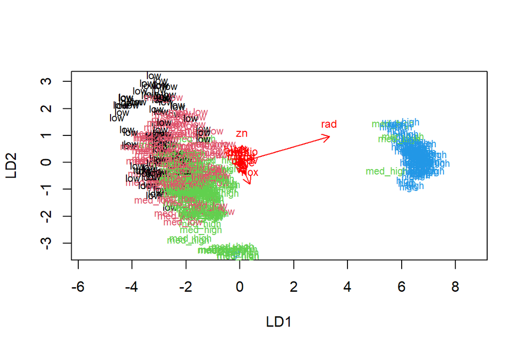

```r
# the function for lda biplot arrows
lda.arrows <- function(x, myscale = 1, arrow_heads = 0.1, color = "red", tex = 0.75, choices = c(1,2)){
  heads <- coef(x)
  graphics::arrows(x0 = 0, y0 = 0,
         x1 = myscale * heads[,choices[1]],
         y1 = myscale * heads[,choices[2]], col=color, length = arrow_heads)
  text(myscale * heads[,choices], labels = row.names(heads),
       cex = tex, col=color, pos=3)
}

# target classes as numeric
classes <- as.numeric(train$crime)

# plot the lda results (select both lines and execute them at the same time!)
plot(lda.fit, dimen = 2, col = classes, pch = classes)
lda.arrows(lda.fit, myscale = 1)
```

Nice plot!

### Part 6: Predicting crime classes in the test data.

```r
#use the previous LDA model with the test data
lda.pred <- predict(lda.fit, newdata = test)
#plot the correct classed (separated before) and cross-tabulate
table(correct = correct_classes, predicted = lda.pred$class)
```

```
##           predicted
## correct    low med_low med_high high
##   low       14      11        3    0
##   med_low    2      15        8    0
##   med_high   0       6       15    2
##   high       0       0        0   26
```

### Part 7: K-means clustering

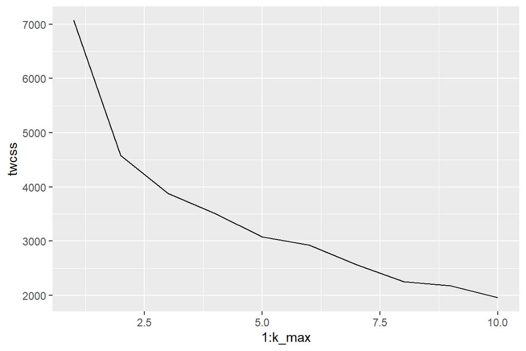

```r
#reload the data
data("Boston")

#standardize the data
boston_scaled <- as.data.frame(scale(Boston))

#calculate distances
dist_eu <- dist(boston_scaled)

set.seed(54656)

# determine the number of clusters
k_max <- 10

# calculate the total within sum of squares
twcss <- sapply(1:k_max, function(k){kmeans(boston_scaled, k)$tot.withinss})

# visualize the results
qplot(x = 1:k_max, y = twcss, geom = 'line')
```

It seems that the optimal number of clusters is three, using the elbow method. However, it is not totally unambiguous, case could be made that the optimum would be two or five. Let’s use three nevertheless.

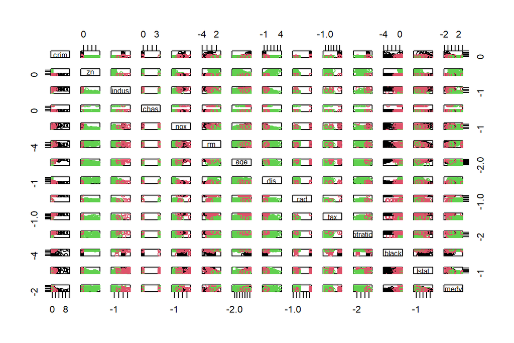

```r
# k-means clustering with two clusters
km <- kmeans(boston_scaled, centers = 3)
# plot the Boston dataset with these clusters
pairs(boston_scaled, col = km$cluster)
```

Here’s the plot. There are too many variable pairs to try a concise interpretation. There seem to be two clusters (red and black) and large “other” cluster (“green”). There are differences between variable pairs where clustering performs better and some where it performs worse. Would be easier to interpret with slightly less variables.

# Chapter 5: Dimensionality reduction

load required libraries

```r
library(tidyverse)
library(psych)
library(corrplot)
library(tibble)
library(FactoMineR)
```

### Part 1: Overview

Read the data on transpose columns to rows

```r
human = read.csv('data/human.csv',header = TRUE)
human_ <- column_to_rownames(human, "Country")
```

Check the distributions and correlations between variables

```r
describe(human)
```

```
##           vars   n     mean       sd   median  trimmed      mad    min
## Country*     1 155    78.00    44.89    78.00    78.00    57.82   1.00
## Edu2.FM      2 155     0.85     0.24     0.94     0.87     0.12   0.17
## Labo.FM      3 155     0.71     0.20     0.75     0.73     0.17   0.19
## Life.Exp     4 155    71.65     8.33    74.20    72.40     7.56  49.00
## Edu.Exp      5 155    13.18     2.84    13.50    13.24     2.97   5.40
## GNI          6 155 17627.90 18543.85 12040.00 14552.58 13337.47 581.00
## Mat.Mor      7 155   149.08   211.79    49.00   104.70    63.75   1.00
## Ado.Birth    8 155    47.16    41.11    33.60    41.62    35.73   0.60
## Parli.F      9 155    20.91    11.49    19.30    20.32    11.42   0.00
##                 max     range  skew kurtosis      se
## Country*     155.00    154.00  0.00    -1.22    3.61
## Edu2.FM        1.50      1.33 -0.76     0.55    0.02
## Labo.FM        1.04      0.85 -0.87     0.05    0.02
## Life.Exp      83.50     34.50 -0.76    -0.15    0.67
## Edu.Exp       20.20     14.80 -0.20    -0.34    0.23
## GNI       123124.00 122543.00  2.14     6.83 1489.48
## Mat.Mor     1100.00   1099.00  2.03     4.16   17.01
## Ado.Birth    204.80    204.20  1.13     0.89    3.30
## Parli.F       57.50     57.50  0.55    -0.10    0.92
```

```r
cor(human_)
```

```
##                Edu2.FM      Labo.FM   Life.Exp     Edu.Exp         GNI
## Edu2.FM    1.000000000  0.009564039  0.5760299  0.59325156  0.43030485
## Labo.FM    0.009564039  1.000000000 -0.1400125  0.04732183 -0.02173971
## Life.Exp   0.576029853 -0.140012504  1.0000000  0.78943917  0.62666411
## Edu.Exp    0.593251562  0.047321827  0.7894392  1.00000000  0.62433940
## GNI        0.430304846 -0.021739705  0.6266641  0.62433940  1.00000000
## Mat.Mor   -0.660931770  0.240461075 -0.8571684 -0.73570257 -0.49516234
## Ado.Birth -0.529418415  0.120158862 -0.7291774 -0.70356489 -0.55656208
## Parli.F    0.078635285  0.250232608  0.1700863  0.20608156  0.08920818
##              Mat.Mor  Ado.Birth     Parli.F
## Edu2.FM   -0.6609318 -0.5294184  0.07863528
## Labo.FM    0.2404611  0.1201589  0.25023261
## Life.Exp  -0.8571684 -0.7291774  0.17008631
## Edu.Exp   -0.7357026 -0.7035649  0.20608156
## GNI       -0.4951623 -0.5565621  0.08920818
## Mat.Mor    1.0000000  0.7586615 -0.08944000
## Ado.Birth  0.7586615  1.0000000 -0.07087810
## Parli.F   -0.0894400 -0.0708781  1.00000000
```

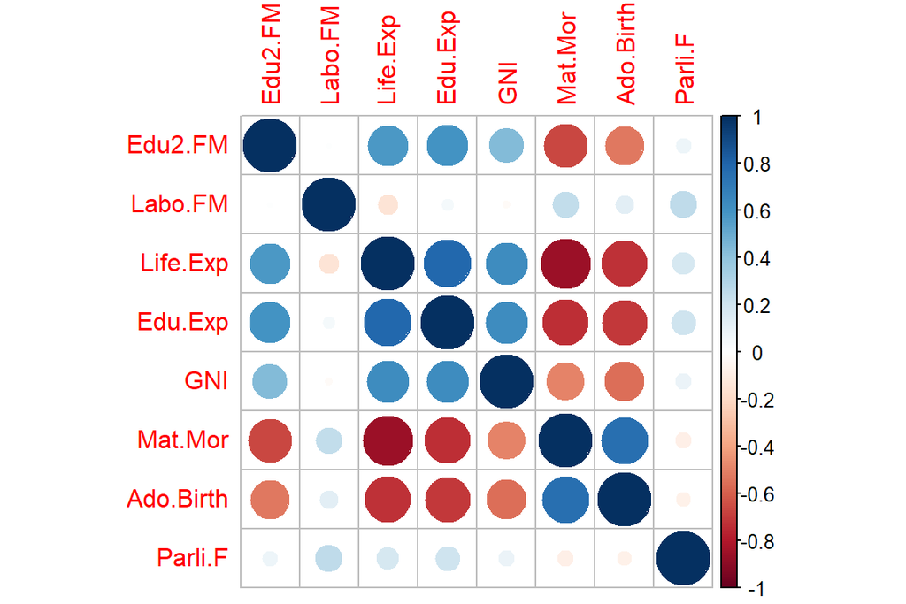

```r
corrplot(cor(human_))
```

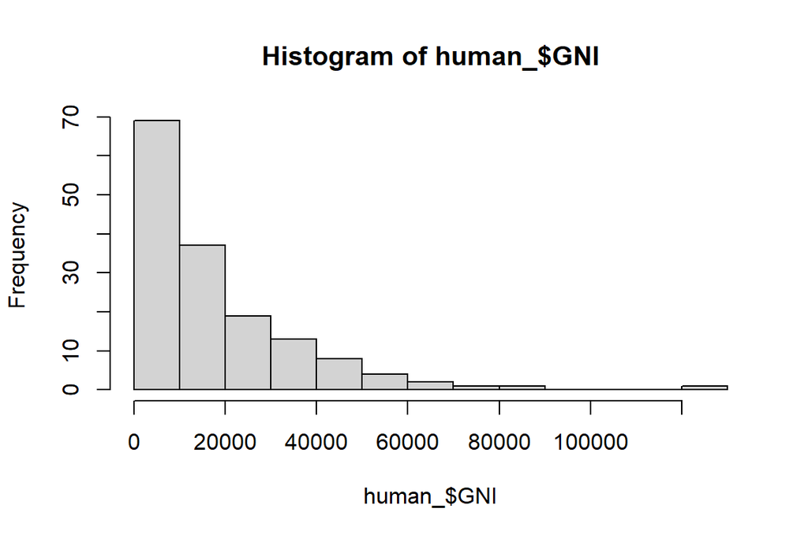

```r
hist(human_$GNI)
```

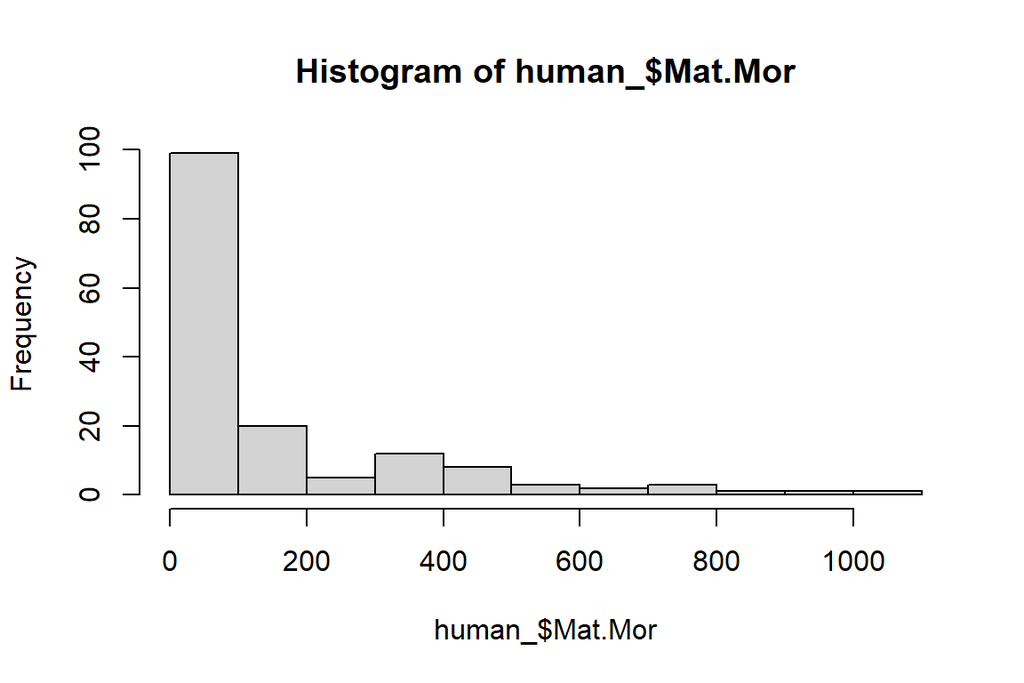

```r
hist(human_$Mat.Mor)
```

GNI and maternal mortality are substantially skewed right. The rest of the variables are reasonably normal regarding skewness and kurtosis values.

Maternal mortality and Adolescent birthrate correlate positively with each other and negatively with Life expectancy, Education, GNI and ratio of secondary education between genders, which form another intercorrelated cluster.

Representation in Parliament and Labor role participation ratio between genders do not correlate with other variables.

### Part 2: PCA on raw data

Calculate and visualize PCA

```r
pca_human <- prcomp(human_)
s <- summary(pca_human)
round(1*s$importance[2, ], digits = 2)
```

```
## PC1 PC2 PC3 PC4 PC5 PC6 PC7 PC8
##   1   0   0   0   0   0   0   0
```

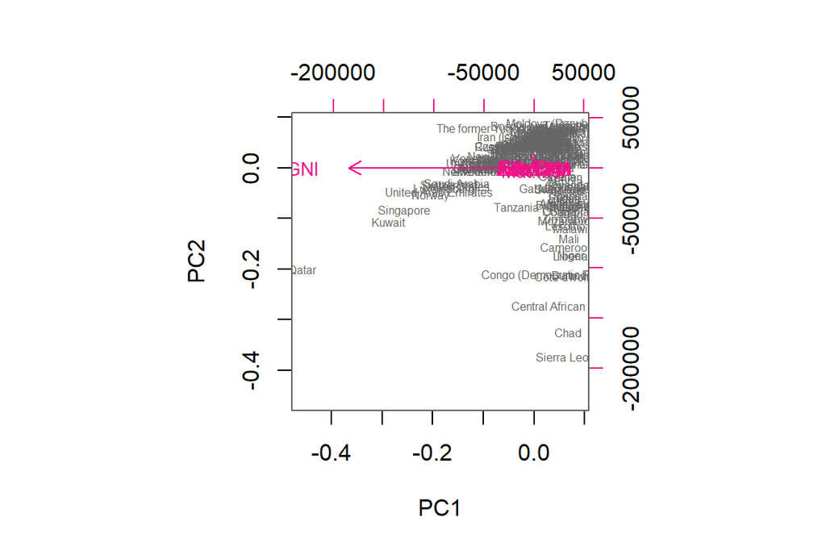

```r
biplot(pca_human, cex = c(0.5, 0.8), col = c("grey40", "deeppink2"))
```

### Part 3: PCA on scaled data

Calculate and visualize PCA using normalized variables

```r
pca_human_z <- prcomp(scale(human_))
s_z <- summary(pca_human_z)
pca_pr_z <- round(100*s_z$importance[2, ], digits = 2)
pca_pr_z
```

```
##   PC1   PC2   PC3   PC4   PC5   PC6   PC7   PC8
## 53.61 16.24  9.57  7.58  5.48  3.60  2.63  1.30
```

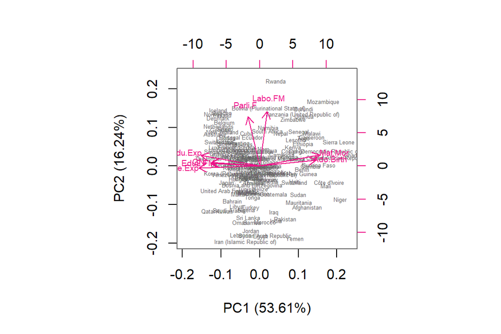

```r
pc_lab<-paste0(names(pca_pr_z), " (", pca_pr_z, "%)")
biplot(pca_human_z, cex = c(0.4, 0.6), col = c("grey40", "deeppink2"),xlab=pc_lab[1],
       ylab=pc_lab[2])
```

*Caption for Figure: PC1 can be interpreted to represent the (negative) development level and prosperity of the society, PC2 represents gender equality. Numbers in parentheses represent accounted variance by the component*

With unstandardized variables, GNI dominates the whole analysis, accounting for 99.99% of variance via the first component, making the analysis useless. It is clearly very important to scale the variables when doing dimensionality reduction!

With standardized variables, we get two components accounting for ~70% of the total variance and possible interpretations.

### Part 4: Interpretation of the components

component 2 can be interpreted to represent gender equality, loaded by parliamentary representation of females and labor force participation ratio between the sexes.

Components are orthogonal, indicating the they are, to a degree, independent factors withing countries.

### Part 5: It’s teatime!

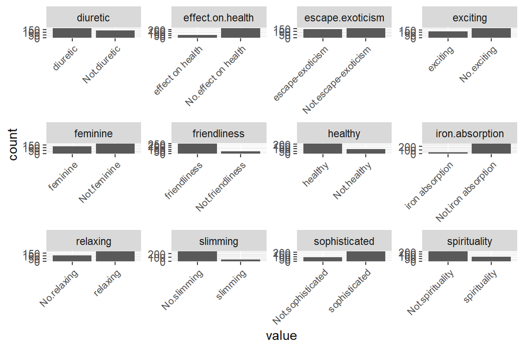

```r
#read the data
tea <- read.csv("https://raw.githubusercontent.com/KimmoVehkalahti/Helsinki-Open-Data-Science/master/datasets/tea.csv", stringsAsFactors = TRUE)

#check data, comment out
#view(tea)

#Let's use the perception variables from the last 12 columns of the data
tea_perc<-tea[,25:36]

#plot the responses
pivot_longer(tea_perc, cols = everything()) %>%
  ggplot(aes(value)) + geom_bar()+ facet_wrap("name", scales = "free")+ theme(axis.text.x = element_text(angle = 45, hjust = 1, size = 8))
```

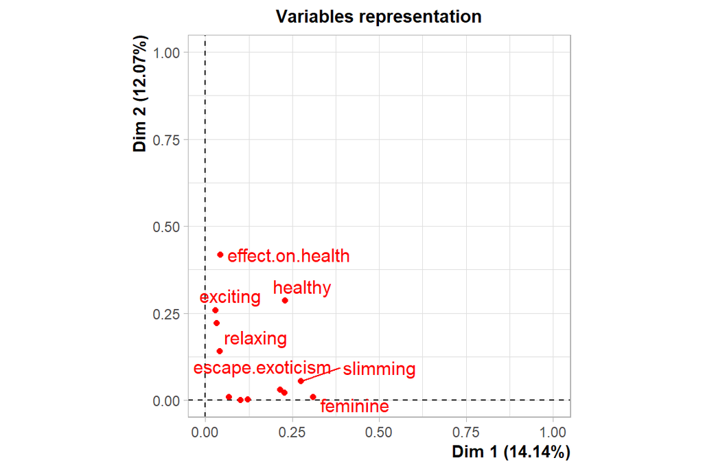

```r
#run MCA
mca <- MCA(tea_perc, graph = TRUE)
```

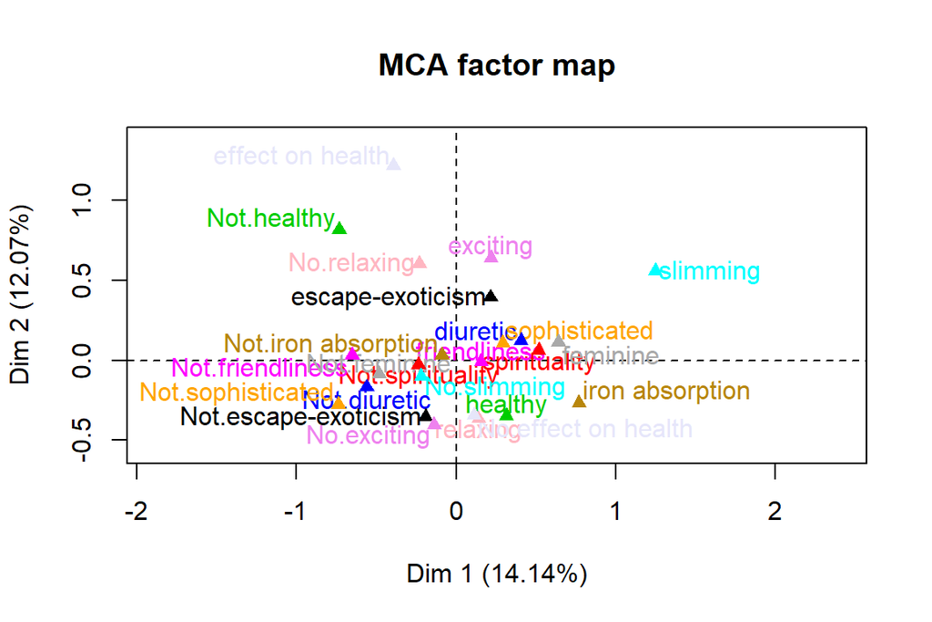

```r
#plot the biplot
plot(mca, invisible=c("ind"), graph.type = "classic", habillage = "quali")
```

MCA was conducted on the variables detailing the perception of tea brands.

The two-component solution explains only quarter of the variance. The first dimension can be interpreted as positive/feminine vs negative/non-feminine definition of the product (DEFINITIONS). Second dimensions concerns health, excitability and vigour (EFFECTS).

More research is needed….

# Chapter 6: Longitudinal data

load required libraries

```r
library(tidyverse)
library(psych)
library(corrplot)
library(ggplot2)
library(lme4)
library(Matrix)
library(car)
library(lmerTest)
```

### Part 1: Chapter 8 MABS analysis using RATS data

Read in the RATS data and convert to long form

```r
RATS <- read.table("https://raw.githubusercontent.com/KimmoVehkalahti/MABS/master/Examples/data/rats.txt", header = TRUE, sep = '\t')

RATS$ID <- factor(RATS$ID)
RATS$Group <- factor(RATS$Group)

RATSL <-  pivot_longer(RATS, cols = -c(ID, Group),
                       names_to = "weekdays", values_to = "rats") %>%
  arrange(weekdays)

RATSL <-  RATSL %>%
  mutate(time = as.integer(substr(weekdays,3,4)))
```

Plot the rat weight data by Time and Group

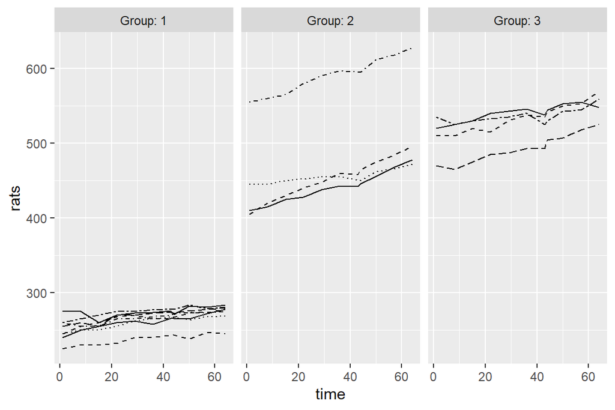

```r
ggplot(RATSL, aes(x = time, y = rats, linetype = ID)) +
  geom_line() +
  scale_linetype_manual(values = rep(1:8, times=2)) +
  facet_grid(. ~ Group, labeller = label_both) +
  theme(legend.position = "none") +
  scale_y_continuous(limits = c(min(RATSL$rats), max(RATSL$rats)))
```

Standardize by week and plot the standardized (by week) data by Time and Group

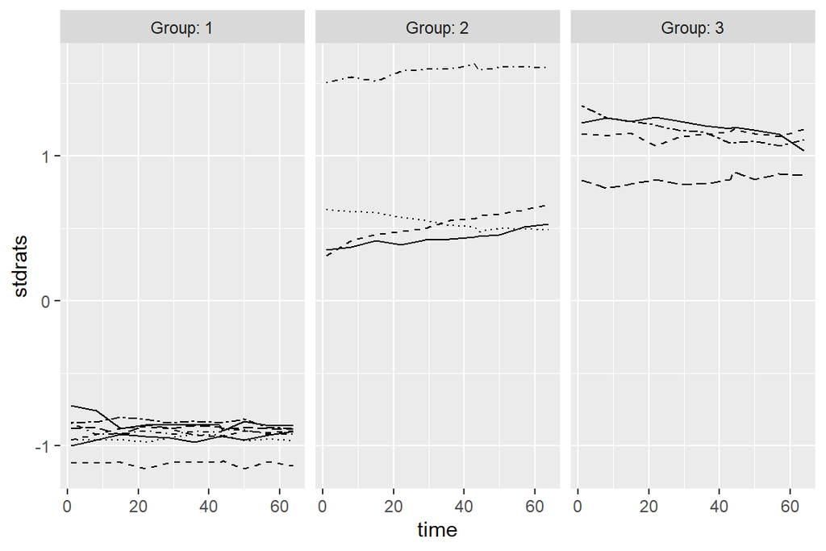

```r
RATSL <- RATSL %>%
  group_by(time) %>%
  mutate(stdrats = scale(rats)) %>%
  ungroup()


ggplot(RATSL, aes(x = time, y = stdrats, linetype = ID)) +
  geom_line() +
  scale_linetype_manual(values = rep(1:8, times=2)) +
  facet_grid(. ~ Group, labeller = label_both) +
  theme(legend.position = "none") +
  scale_y_continuous(limits = c(min(RATSL$stdrats), max(RATSL$stdrats)))
```

Groups 2 and 3 have much larger scores. There is an outlier in Group 2, a fat rat.

Plot mean and standard deviation by group. Used SD instead of SE since the group sizes differ.

```r
RATSS <- RATSL %>%
  group_by(Group, time) %>%
  summarise(mean =mean(rats), se = sd(rats)) %>%
  ungroup()
```

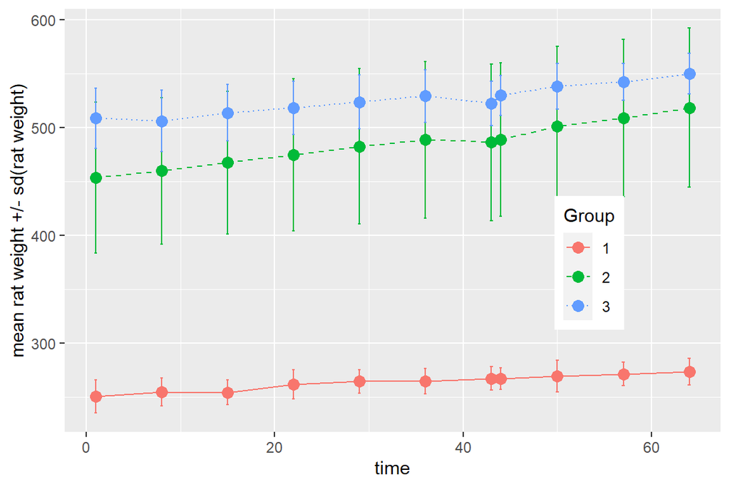

```r
ggplot(RATSS, aes(x = time, y = mean, linetype = Group, colour = Group)) +
  geom_line() +
  scale_linetype_manual(values = c(1,2,3)) +
  geom_point(size=3) +
  scale_shape_manual(values = c(1,2,3)) +
  geom_errorbar(aes(ymin=mean-se, ymax=mean+se, linetype="1"), width=0.3) +
  theme(legend.position = c(0.8,0.4)) +
  scale_y_continuous(name = "mean rat weight +/- sd(rat weight)")
```

Group 2 has large deviations, suggesting the presence of an outlier detected earlier.

Remove the outlier (ID=12) and make a boxplot per group.

```r
#Means with the outlier
RATSD2 <- RATSL %>%
 #filter(ID!=12)  %>%
 #filter(week > 0) %>%
  group_by(Group, ID) %>%
  summarise( mean=mean(rats) ) %>%
  ungroup()
#Means without the ourlier
RATSD <- RATSL %>%
  filter(ID!=12)  %>%
 #filter(week > 0) %>%
  group_by(Group, ID) %>%
  summarise( mean=mean(rats) ) %>%
  ungroup()
```

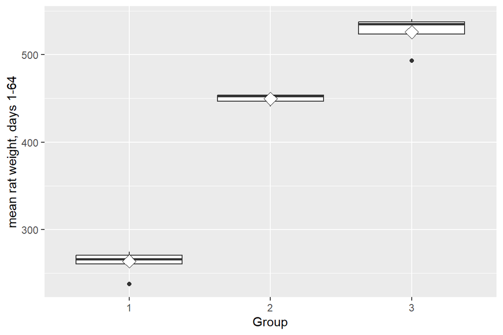

```r
ggplot(RATSD, aes(x = Group, y = mean)) +
  geom_boxplot() +
  stat_summary(fun = "mean", geom = "point", shape=23, size=4, fill = "white") +
  scale_y_continuous(name = "mean rat weight, days 1-64")
```

There are outliers in group 1 and group 3 as well but let’s leave them be. Testing for group differences with the original outlier removed.

```r
t.test(mean ~ Group, data = filter(RATSD,Group!=3), var.equal = TRUE)
```

```
##
##  Two Sample t-test
##
## data:  mean by Group
## t = -24.838, df = 9, p-value = 1.334e-09
## alternative hypothesis: true difference in means between group 1 and group 2 is not equal to 0
## 95 percent confidence interval:
##  -202.6549 -168.8224
## sample estimates:
## mean in group 1 mean in group 2
##        263.7159        449.4545
```

```r
t.test(mean ~ Group, data = filter(RATSD,Group!=2), var.equal = TRUE)
```

```
##
##  Two Sample t-test
##
## data:  mean by Group
## t = -27.361, df = 10, p-value = 9.848e-11
## alternative hypothesis: true difference in means between group 1 and group 3 is not equal to 0
## 95 percent confidence interval:
##  -283.4218 -240.7373
## sample estimates:
## mean in group 1 mean in group 3
##        263.7159        525.7955
```

```r
t.test(mean ~ Group, data = filter(RATSD,Group!=1), var.equal = TRUE)
```

```
##
##  Two Sample t-test
##
## data:  mean by Group
## t = -5.6287, df = 5, p-value = 0.002452
## alternative hypothesis: true difference in means between group 2 and group 3 is not equal to 0
## 95 percent confidence interval:
##  -111.20490  -41.47691
## sample estimates:
## mean in group 2 mean in group 3
##        449.4545        525.7955
```

All differences are significant at p<0.01 level. Let’s check without the ourlier removed:

```r
t.test(mean ~ Group, data = filter(RATSD2,Group!=3), var.equal = TRUE)
```

```
##
##  Two Sample t-test
##
## data:  mean by Group
## t = -9.0193, df = 10, p-value = 4.059e-06
## alternative hypothesis: true difference in means between group 1 and group 2 is not equal to 0
## 95 percent confidence interval:
##  -275.5817 -166.3956
## sample estimates:
## mean in group 1 mean in group 2
##        263.7159        484.7045
```

```r
t.test(mean ~ Group, data = filter(RATSD2,Group!=2), var.equal = TRUE)
```

```
##
##  Two Sample t-test
##
## data:  mean by Group
## t = -27.361, df = 10, p-value = 9.848e-11
## alternative hypothesis: true difference in means between group 1 and group 3 is not equal to 0
## 95 percent confidence interval:
##  -283.4218 -240.7373
## sample estimates:
## mean in group 1 mean in group 3
##        263.7159        525.7955
```

```r
t.test(mean ~ Group, data = filter(RATSD2,Group!=1), var.equal = TRUE)
```

```
##
##  Two Sample t-test
##
## data:  mean by Group
## t = -1.1086, df = 6, p-value = 0.3101
## alternative hypothesis: true difference in means between group 2 and group 3 is not equal to 0
## 95 percent confidence interval:
##  -131.79027   49.60845
## sample estimates:
## mean in group 2 mean in group 3
##        484.7045        525.7955
```

When the outlier in Group 2 remains, there difference between Group 2 and Group 3 is non-significant.

```r
rm(RATSD2)
RATSD2 <- RATSL %>%
  filter(time > 0) %>%
  group_by(Group, ID) %>%
  summarise( mean=mean(rats) ) %>%
  ungroup()
RATSB_WITHOUT <- RATSD2 %>%
  mutate(baseline = RATS$WD1)  %>%
   filter(ID!=12)

RATSB_WITH <- RATSD2 %>%
  mutate(baseline = RATS$WD1)
```

Fit the linear model with Group and baseline. Use car library to print ANOVA table.

```r
fit <- lm(mean ~ Group + baseline, data = RATSB_WITHOUT)
Anova(fit, type="III")
```

```
## Anova Table (Type III tests)
##
## Response: mean
##              Sum Sq Df F value    Pr(>F)
## (Intercept)  915.40  1 14.4702 0.0029231 **
## Group       1225.72  2  9.6878 0.0037478 **
## baseline    1864.80  1 29.4780 0.0002072 ***
## Residuals    695.87 11
## ---
## Signif. codes:  0 '***' 0.001 '**' 0.01 '*' 0.05 '.' 0.1 ' ' 1
```

When controlling for the first day baseline, there are still significant differences between groups at later days. Lets’ check with the outlier included.

```r
fit <- lm(mean ~ Group + baseline, data = RATSB_WITH)
Anova(fit, type="III")
```

```
## Anova Table (Type III tests)
##
## Response: mean
##              Sum Sq Df  F value    Pr(>F)
## (Intercept)   259.0  1   2.2981   0.15542
## Group         726.2  2   3.2219   0.07586 .
## baseline    16119.0  1 143.0215 5.023e-08 ***
## Residuals    1352.4 12
## ---
## Signif. codes:  0 '***' 0.001 '**' 0.01 '*' 0.05 '.' 0.1 ' ' 1
```

When the outlier in Group 2 is not removed, the difference between the groups becomes trending (p<0.10). Baseline still highly significant.